# Check EMA

Hannah, Sarah, Megan

2020-07-14

### Notes

The goal of this script is to chracterize and look for errors in the EMA data for RISK.

### Setup

Paths

```r
data_path <- "P:/StudyData/RISK/analysis/shared/data"
```

Packages and Source

```r
library(tidyverse)
library(janitor)
library(lmSupport)
library(knitr)
library(mice)
library(lubridate)
library(data.table)
```

### Read in data and glimpse

```r
ema <- read_rds(file.path(data_path, "ds_ema.rds")) %>%
  mutate( #convert unix time to dttm
    time = as_datetime(utc, tz = 'America/Chicago'),
    day = date(time), #store day for grouping
    hour = hour(time), #store time
    start_date = as_datetime(start_date, tz = 'America/Chicago'),
    end_date = as_datetime(end_date, tz = 'America/Chicago')) %>%
  select(-utc, -response_id) %>%
  as.data.table() %>% #to speed processing
  glimpse()

lapses <- read_rds(file.path(data_path, "ds_lapses.rds"))
id <- read_rds(file.path(data_path, "ds_id.rds"))
```

```
## Rows: 43,803
## Columns: 20
## $ subid      <int> 1, 1, 1, 1, 1, 1, 1, 1, 1, 1, 1, 1, 1, 1, 1, 1, 1, 1, 1,...
## $ start_date <dttm> 2017-03-02 09:17:11, 2017-03-02 14:27:53, 2017-03-02 21...
## $ end_date   <dttm> 2017-03-02 09:20:19, 2017-03-02 14:37:43, 2017-03-02 21...
## $ ema_1      <dbl> 1, 1, 1, 1, 1, 1, 1, 1, 1, 1, 1, 1, 1, 1, 1, 1, 1, 1, 1,...
## $ ema_1_1    <dttm> NA, NA, NA, NA, NA, NA, NA, NA, NA, NA, NA, NA, NA, NA,...
## $ ema_1_3    <dttm> NA, NA, NA, NA, NA, NA, NA, NA, NA, NA, NA, NA, NA, NA,...
## $ ema_1_5    <dbl> NA, NA, NA, NA, NA, NA, NA, NA, NA, NA, NA, NA, NA, NA, ...
## $ ema_2      <dbl> 4, 5, 1, 2, 1, 3, 3, 2, 1, 3, 2, 3, 4, 1, 2, 2, 3, 3, 3,...
## $ ema_3      <dbl> 12, 11, 4, 4, 0, 2, 4, 0, 3, 1, 1, 4, 5, 1, 4, 2, 6, 3, ...
## $ ema_4      <dbl> 12, 10, 4, 4, 0, 0, 4, 0, 2, 4, 4, 4, 4, 1, 8, 2, 1, 3, ...
## $ ema_5      <dbl> 8, 8, 4, 8, 0, 8, 5, 5, 4, 3, 8, 7, 2, 4, 5, 4, 4, 2, 4,...
## $ ema_6      <dbl> 6, 7, 8, 6, 7, 9, 8, 6, 8, 7, 8, 8, 5, 7, 9, 8, 4, 8, 4,...
## $ ema_7      <dbl> 8, 7, 7, 3, 8, 6, 7, 3, 7, 8, 8, 7, 6, 8, 5, 7, 4, 4, 5,...
## $ ema_8      <dbl> 5, NA, NA, 5, NA, NA, NA, 4, NA, NA, 7, 5, NA, 6, NA, NA...
## $ ema_9      <dbl> 5, NA, NA, 7, NA, NA, NA, 6, NA, NA, 5, 6, NA, 6, NA, NA...
## $ ema_10     <dbl> 4, NA, NA, 4, NA, NA, NA, 4, NA, NA, 4, 5, NA, 5, NA, NA...
## $ type       <int> 1, 2, 2, 1, 2, 2, 2, 1, 2, 2, 1, 1, 2, 1, 2, 2, 1, 2, 2,...
## $ time       <dttm> 2017-03-02 09:17:11, 2017-03-02 14:27:53, 2017-03-02 21...
## $ day        <date> 2017-03-02, 2017-03-02, 2017-03-02, 2017-03-03, 2017-03...
## $ hour       <int> 9, 14, 21, 6, 8, 6, 10, 6, 12, 15, 6, 11, 13, 6, 13, 18,...
```

##Basic descriptives and properties

Number of EMA Observations

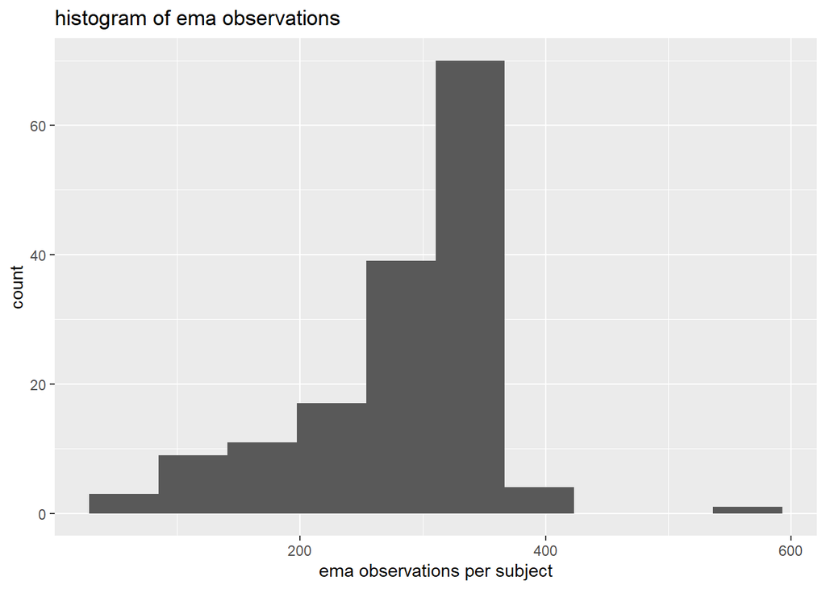

```r
counts <- ema %>%
  group_by(subid) %>%
  summarize(n = n()) %>%
  varDescribe() %>%
  filter(vars == 2)

ema %>%
  group_by(subid) %>%
  summarize(n = n()) %>%
  ggplot(aes(x = n)) +
  geom_histogram(bins = 10) +
  xlab("ema observations per subject") +
  ggtitle("histogram of ema observations")
```

There are 43803 rows from 154 subjects, who contributed an average of 284.44 observations (range 51 - 559).

Morning surveys

```r
counts_am <- ema %>%
  group_by(subid) %>%
  filter(type == 1) %>% #morning
  summarize(n = n()) %>%
  select(subid, n) %>%
  varDescribe() %>%
  filter(vars == 2)

#per day
counts_am_perday <- ema %>% group_by(subid, day) %>%
  filter(type == 1) %>% #morning
  summarize(n = n()) %>%
  select(subid, n) %>%
  varDescribe() %>%
  filter(vars == 2)
```

154 subjects contributed an average of 71.07 total morning observations (range 1 - 163) and an average of 1.05 morning surveys per day (range 1 - 5).

Afternoon surveys

```r
counts_pm <- ema %>% group_by(subid) %>%
  filter(type == 2) %>%
  summarize(n = n()) %>%
  select(subid, n) %>%
  varDescribe() %>%
  filter(vars == 2)

counts_pm_perday <- ema %>% group_by(subid, day) %>%
  filter(type == 2) %>%
  summarize(n = n()) %>%
  select(subid, n) %>%
  varDescribe() %>%
  filter(vars == 2)
```

154 subjects contributed an average of 213.36 total day observations (range 39 - 396) and an average of 2.68 day surveys per day (range 1 - 12).

Histograms of Observation Counts

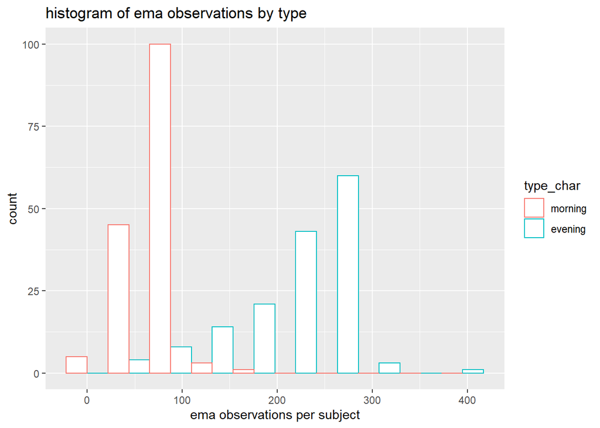

```r
ema %>%
  mutate(type_char = as_factor(case_when(type == 1 ~ "morning",
                                         type == 2 ~ "evening"))) %>%
  group_by(subid, type_char) %>%
  summarize(n = n()) %>%
  ungroup() %>%
  ggplot(aes(x = n, color = type_char)) +
  geom_histogram(bins = 10, fill = "white", position = "dodge") +
  xlab("ema observations per subject") +
  ggtitle("histogram of ema observations by type")
```

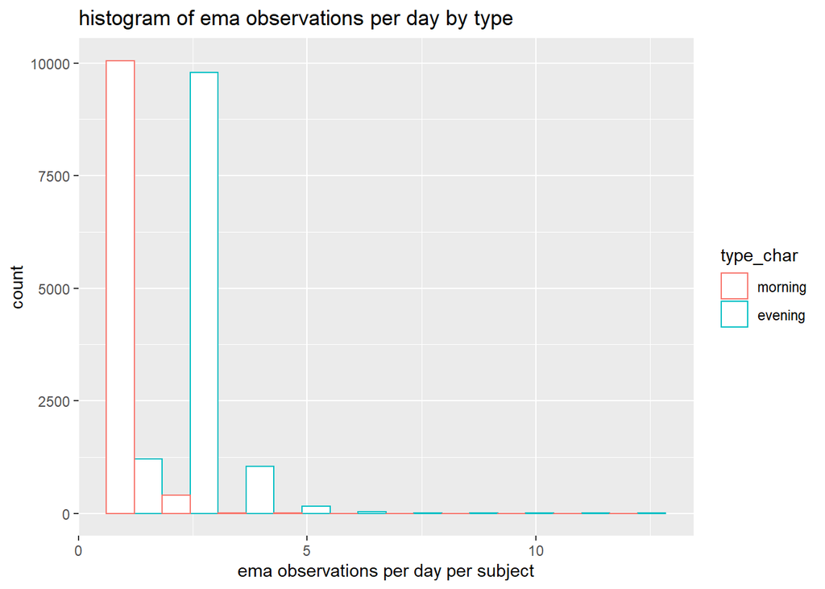

```r
ema %>%
  mutate(type_char = as_factor(case_when(type == 1 ~ "morning",
                                         type == 2 ~ "evening"))) %>%
  group_by(subid, type_char, day) %>%
  summarize(n = n()) %>%
  ungroup() %>%
  ggplot(aes(x = n, color = type_char)) +
  geom_histogram(bins = 10, fill = "white", position = "dodge") +
  xlab("ema observations per day per subject") +
  ggtitle("histogram of ema observations per day by type")
```

Timing of Observations

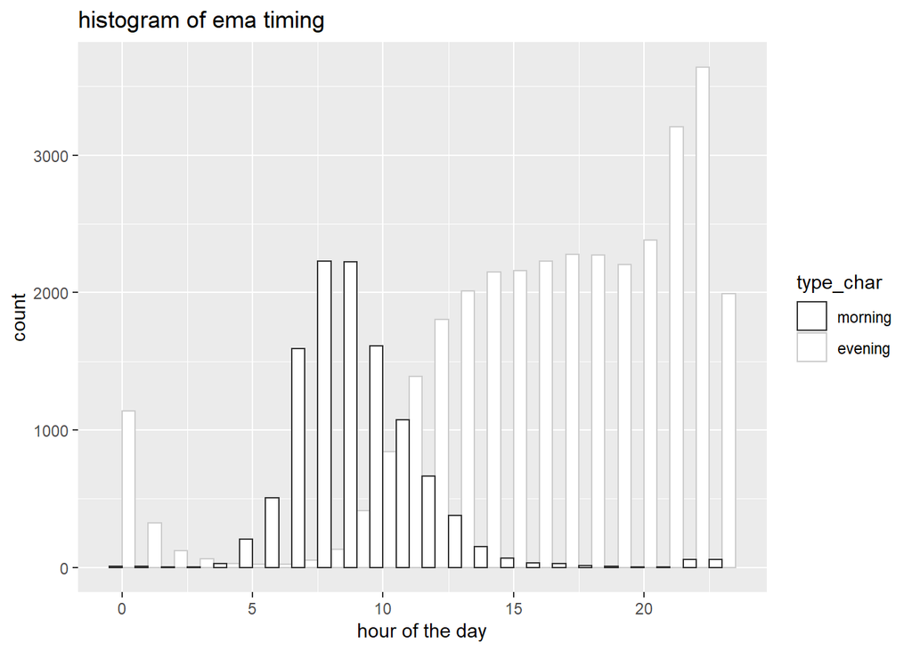

```r
ema %>%
  mutate(end_hour = hour(end_date)) %>% #get the time in hour of the day
  mutate(type_char = as_factor(case_when(type == 1 ~ "morning",
                         type == 2 ~ "evening"))) %>%
  ggplot(aes(x = end_hour, color = type_char)) +
  geom_histogram(fill = "white", position = "dodge", binwidth = 1) +
  scale_color_grey() +
  xlab("hour of the day") +
  ggtitle("histogram of ema timing")
```

```r
ema %>%
  mutate(end_hour = hour(end_date)) %>%
  filter(type == 1) %>%
  summarize(median_am_ema_time = median(end_hour, na.rm = TRUE))

ema %>%
  mutate(end_hour = hour(end_date)) %>%
  filter(type == 1) %>%
  tabyl(end_hour) %>%
  filter(end_hour < 13, end_hour > 5) %>%
  mutate(percent = round(percent, 2))
```

```
##   median_am_ema_time
## 1                  9
##  end_hour    n percent
##         6  505    0.05
##         7 1592    0.15
##         8 2228    0.20
##         9 2225    0.20
##        10 1611    0.15
##        11 1073    0.10
##        12  664    0.06
```

### Duplicate Surveys per Day

```r
n_duplicated <-  ema %>% filter(duplicated(ema) == TRUE) %>% nrow()

n_incomplete <- ema %>% group_by(subid, day) %>%
  filter(type == 1) %>%
  mutate(am_count = cumsum(type)) %>%
  filter(am_count > 1) %>%
  mutate(missing = is.na(ema_10)) %>%
  filter(missing > 0) %>% nrow()

n_startisnotutc <- ema %>% filter(start_date != time) %>% nrow()
n_startdayisnotutcday <- ema %>% filter(substr(start_date, 1, 10) != substr(time, 1, 10)) %>% nrow()

n_lapsedataonly <- ema %>% filter(ema_1 != 'NA' & ema_3 == 'NA') %>%  nrow()
```

Looking at the data and speaking to project staff, we determined that the following reasons **do** **not** explain many surveys per day:  
1. Duplicate surveys (number of duplicates is 0)  
2. People starting but not finishing (no, removed in cleaning; number of incompletes is 0)  
3. Incorrect ‘time’ - No, the time variable is the Qulatrics start time, which is different for 13517 people. Looking just at the dates (not the time), only 0 are different for utc and start date.

#### Looking closely at people with many *morning* surveys per day

People with at least one instance of 5 surveys per day

```r
id_5inaday <- ema %>%
  group_by(subid, day) %>%
  filter(type == 1) %>%
  count() %>%
  filter(n == 5) %>%
  .$subid %>%
  unique()
```

2 subjects had 5 morning surveys per day, giving many similar responses in a short span. For example:

```r
ema %>%
  filter(
    subid == id_5inaday[1],
    day == "2018-08-16",
    type == 1) %>%
  select(subid, day, time, ema_1, ema_2, ema_3, ema_4, ema_5, ema_6, ema_7, ema_8, ema_9, ema_10) %>%
  kable()
```

| subid | day | time | ema_1 | ema_2 | ema_3 | ema_4 | ema_5 | ema_6 | ema_7 | ema_8 | ema_9 | ema_10 |
| --- | --- | --- | --- | --- | --- | --- | --- | --- | --- | --- | --- | --- |
| 79 | 2018-08-16 | 2018-08-16 12:15:38 | 1 | 4 | 7 | 7 | 2 | 8 | 3 | 8 | 8 | 3 |
| 79 | 2018-08-16 | 2018-08-16 12:17:50 | 1 | 3 | 7 | 7 | 2 | 8 | 5 | 7 | 7 | 2 |
| 79 | 2018-08-16 | 2018-08-16 12:46:07 | 1 | 6 | 7 | 8 | 3 | 8 | 4 | 7 | 8 | 2 |
| 79 | 2018-08-16 | 2018-08-16 12:55:02 | 1 | 3 | 7 | 7 | 2 | 7 | 4 | 7 | 8 | 3 |
| 79 | 2018-08-16 | 2018-08-16 13:00:23 | 1 | 3 | 5 | 5 | 2 | 9 | 4 | 7 | 7 | 2 |

People with at least one instance of 4 surveys per day

```r
id_4inaday <- ema %>%
  group_by(subid, day) %>%
  filter(type == 1) %>%
  summarize(n = n()) %>%
  filter(n == 4)
```

2 subjects had 4 morning surveys per day, giving many similar responses in a short span. For example:

```r
ema %>%
  filter(
    subid == id_4inaday$subid[1],
    day == "2017-12-24",
    type == 1) %>%
  select(subid, day, time, ema_1, ema_2, ema_3, ema_4, ema_5, ema_6, ema_7, ema_8, ema_9, ema_10) %>%
  kable()
```

| subid | day | time | ema_1 | ema_2 | ema_3 | ema_4 | ema_5 | ema_6 | ema_7 | ema_8 | ema_9 | ema_10 |
| --- | --- | --- | --- | --- | --- | --- | --- | --- | --- | --- | --- | --- |
| 30 | 2017-12-24 | 2017-12-24 10:26:58 | 1 | 0 | 0 | 1 | 11 | 10 | 7 | 11 | 11 | 1 |
| 30 | 2017-12-24 | 2017-12-24 10:27:37 | 1 | 0 | 4 | 3 | 12 | 11 | 10 | 11 | 11 | 1 |
| 30 | 2017-12-24 | 2017-12-24 10:28:26 | 1 | 1 | 0 | 0 | 8 | 11 | 4 | 11 | 11 | 1 |
| 30 | 2017-12-24 | 2017-12-24 10:29:46 | 1 | 0 | 0 | 4 | 12 | 11 | 10 | 11 | 11 | 1 |

People with at least one instance of 3 surveys per day

```r
n_3inaday <- ema %>% group_by(subid, day) %>%
  filter(type == 1) %>%
  summarize(n = n()) %>%
  filter(n == 3) %>%
  arrange(subid) %>%
  group_by(subid) %>%
  summarize(n = n()) %>%
  nrow()
```

12 people had three morning surveys in one day, and some of these people had three morning surveys multiple days.

Cases examined; nothing clearly wrong. Here is a representative example of one day from one subject who often completed many surveys per day:

| subid | day | time | ema_1 | ema_2 | ema_3 | ema_4 | ema_5 | ema_6 | ema_7 | ema_8 | ema_9 | ema_10 |
| --- | --- | --- | --- | --- | --- | --- | --- | --- | --- | --- | --- | --- |
| 185 | 2019-03-04 | 2019-03-04 08:39:14 | 1 | 3 | 2 | 4 | 5 | 8 | 6 | 7 | 10 | 4 |
| 185 | 2019-03-04 | 2019-03-04 08:39:57 | 1 | 4 | 2 | 5 | 3 | 6 | 6 | 4 | 10 | 3 |
| 185 | 2019-03-04 | 2019-03-04 13:24:34 | 1 | 3 | 3 | 8 | 7 | 8 | 6 | 4 | 8 | 4 |

#### Looking closely at people with many *day* surveys per day

People with multiple instances of surveys per day

```r
n_3inaday_pm <- ema %>% group_by(subid, day) %>%
  filter(type == 2) %>%
  summarize(n = n()) %>%
  filter(n == 3) %>% arrange(subid) %>% group_by(subid) %>% summarize(n = n()) %>% nrow()

#who had 10 per day
id_10inaday <- ema %>% group_by(subid, day) %>%
  filter(type == 2) %>%
  summarize(n = n()) %>%
  filter(n == 10) %>% .$subid
```

Cases examined; nothing clearly wrong. Here is a representative example of one day from someone who often completed many surveys per day:

```r
ema %>% filter(subid == 53,
               day == "2018-03-30",
               type ==2) %>%
  select(subid, day, time, num_range("ema_", 1:7)) %>%
  kable()
```

| subid | day | time | ema_1 | ema_2 | ema_3 | ema_4 | ema_5 | ema_6 | ema_7 |
| --- | --- | --- | --- | --- | --- | --- | --- | --- | --- |
| 53 | 2018-03-30 | 2018-03-30 00:00:38 | 1 | 11 | 6 | 12 | 0 | 1 | 11 |
| 53 | 2018-03-30 | 2018-03-30 00:13:58 | 1 | 1 | 1 | 0 | 0 | 1 | 5 |
| 53 | 2018-03-30 | 2018-03-30 12:55:35 | 1 | 0 | 0 | 0 | 0 | 11 | 1 |
| 53 | 2018-03-30 | 2018-03-30 18:20:42 | 1 | 0 | 0 | 7 | 4 | 9 | 3 |
| 53 | 2018-03-30 | 2018-03-30 19:11:01 | 1 | 0 | 0 | 0 | 0 | 8 | 4 |
| 53 | 2018-03-30 | 2018-03-30 22:07:34 | 1 | 0 | 0 | 0 | 0 | 8 | 8 |

### Characterizing the data

```r
ema %>%
  select(-type, -subid, -end_date, -day, -time, -start_date, -ema_1_1, -ema_1_3, -time, -day, -hour) %>%
  varDescribe(2) %>%
  select(-vars) %>%
  kable()
```

|  | n | mean | sd | median | min | max | skew | kurtosis |
| --- | --- | --- | --- | --- | --- | --- | --- | --- |
| ema_1 | 43803 | 1.03 | 0.17 | 1 | 1 | 2 | 5.44 | 27.65 |
| ema_1_5 | 1340 | 2.50 | 0.56 | 3 | 1 | 3 | -0.55 | -0.73 |
| ema_2 | 43777 | 2.03 | 2.86 | 0 | 0 | 12 | 1.55 | 1.84 |
| ema_3 | 43777 | 1.93 | 2.92 | 0 | 0 | 12 | 1.66 | 2.13 |
| ema_4 | 43777 | 2.99 | 3.29 | 2 | 0 | 12 | 0.98 | 0.13 |
| ema_5 | 43777 | 4.17 | 3.59 | 4 | 0 | 12 | 0.48 | -0.78 |
| ema_6 | 43777 | 7.18 | 2.45 | 7 | 1 | 11 | -0.48 | -0.13 |
| ema_7 | 43777 | 5.75 | 2.70 | 6 | 1 | 11 | 0.06 | -0.80 |
| ema_8 | 10942 | 6.35 | 2.95 | 7 | 1 | 11 | -0.20 | -0.87 |
| ema_9 | 10942 | 7.40 | 2.83 | 8 | 1 | 11 | -0.58 | -0.40 |
| ema_10 | 10942 | 3.24 | 2.34 | 3 | 1 | 11 | 1.10 | 0.95 |

#### Event and affect reports

Urge intensity is zero inflated. (“How intense was your greatest urge to drink alcohol?”)

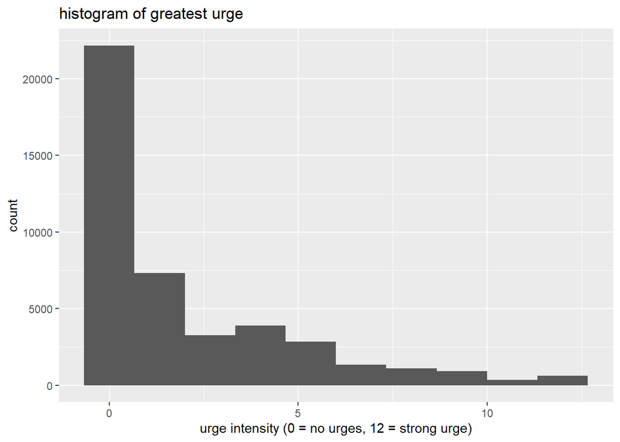

```r
ema %>%
  ggplot(aes(x = ema_2)) +
  geom_histogram(bins = 10) +
  xlab("urge intensity (0 = no urges, 12 = strong urge)") +
  ggtitle("histogram of greatest urge")
```

Risk intensity is zero inflated (“Did you encounter any risky situations (people, places, or things)? If yes, rate the intensity of the situation. If you experienced more than one risky situation, rate the most intense one.”)

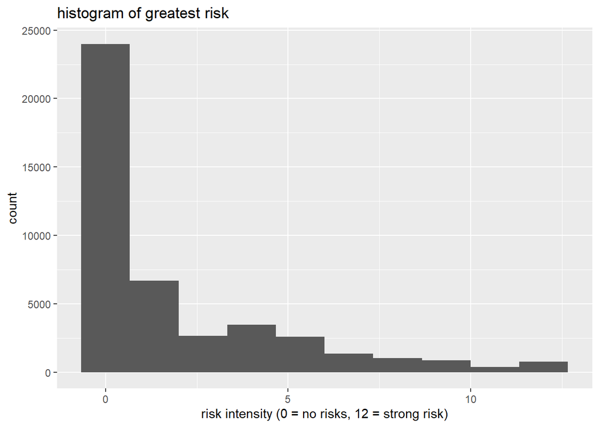

```r
ema %>%
  ggplot(aes(x = ema_3)) +
  geom_histogram(bins = 10) +
  xlab("risk intensity (0 = no risks, 12 = strong risk)") +
  ggtitle("histogram of greatest risk")
```

Stresses and hassles is zero inflated. (“Has a hassle or stressful event occurred? If yes, rate the intensity of the event. If you experienced more than one hassle or stressful event, rate the most intense one.”)

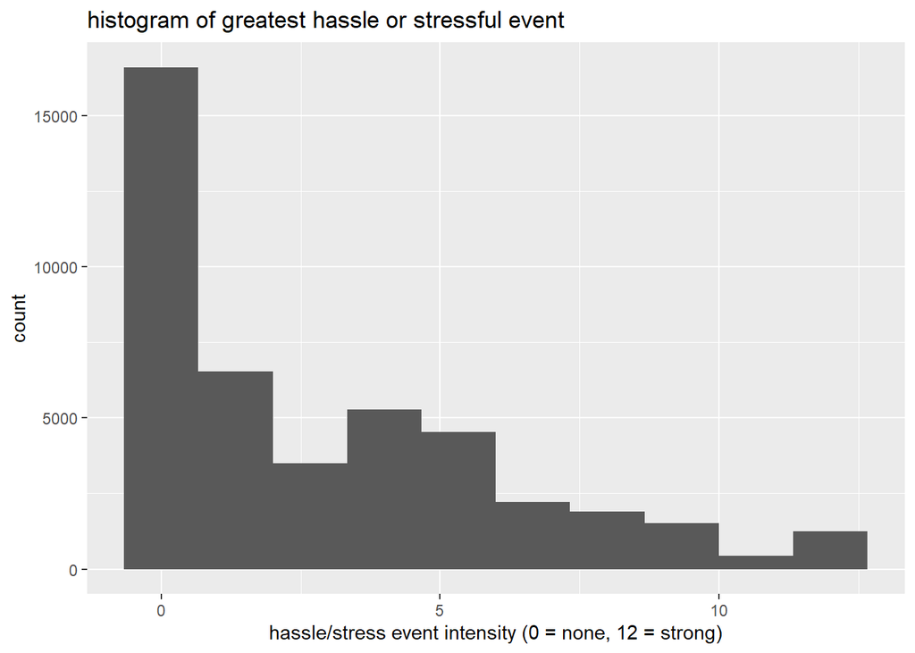

```r
ema %>%
  ggplot(aes(x = ema_4)) +
  geom_histogram(bins = 10) +
  xlab("hassle/stress event intensity (0 = none, 12 = strong)") +
  ggtitle("histogram of greatest hassle or stressful event")
```

Positive events is zero inflated. (“Has a pleasant or positive event occurred? If yes, rate the intensity of the event. If you experienced more than one pleasant or positive event, rate the most intense one.”)

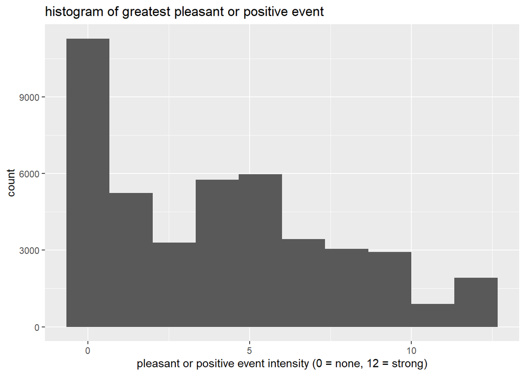

```r
ema %>%
  ggplot(aes(x = ema_5)) +
  geom_histogram(bins = 10) +
  xlab("pleasant or positive event intensity (0 = none, 12 = strong)") +
  ggtitle("histogram of greatest pleasant or positive event")
```

Affect - valence is normally distributed. (“How are you feeling right now”)

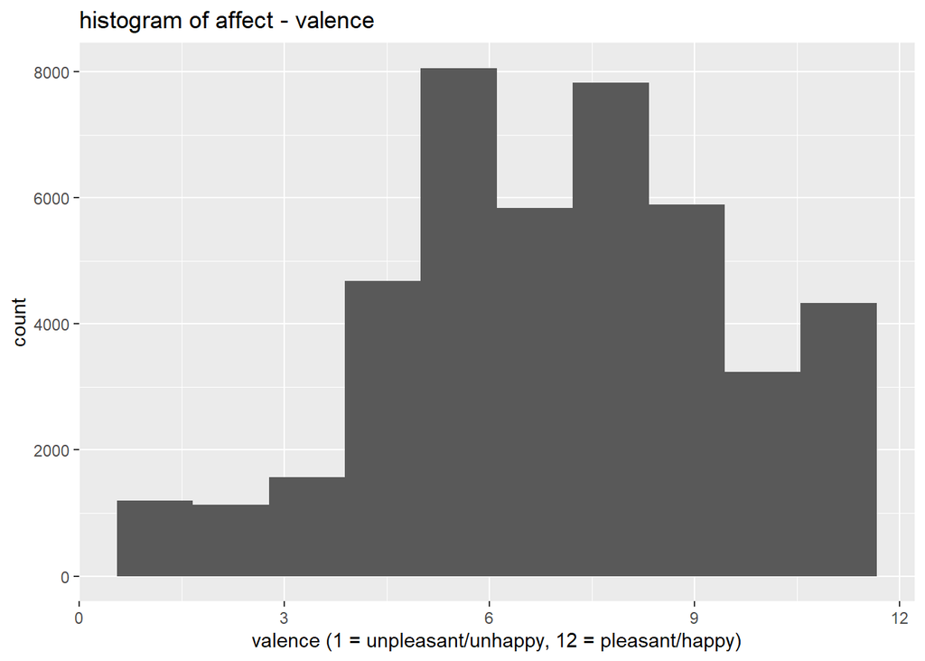

```r
ema %>%
  ggplot(aes(x = ema_6)) +
  geom_histogram(bins = 10) +
  xlab("valence (1 = unpleasant/unhappy, 12 = pleasant/happy)") +
  ggtitle("histogram of affect - valence")
```

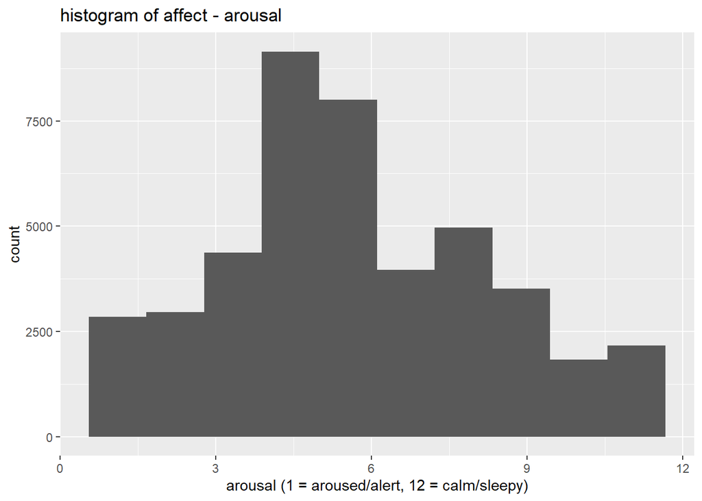

```r
ema %>%
  ggplot(aes(x = ema_7)) +
  geom_histogram(bins = 10) +
  xlab("arousal (1 = aroused/alert, 12 = calm/sleepy)") +
  ggtitle("histogram of affect - arousal")
```

#### Event and affect mean and max per person

Average and max reports of urges per person.

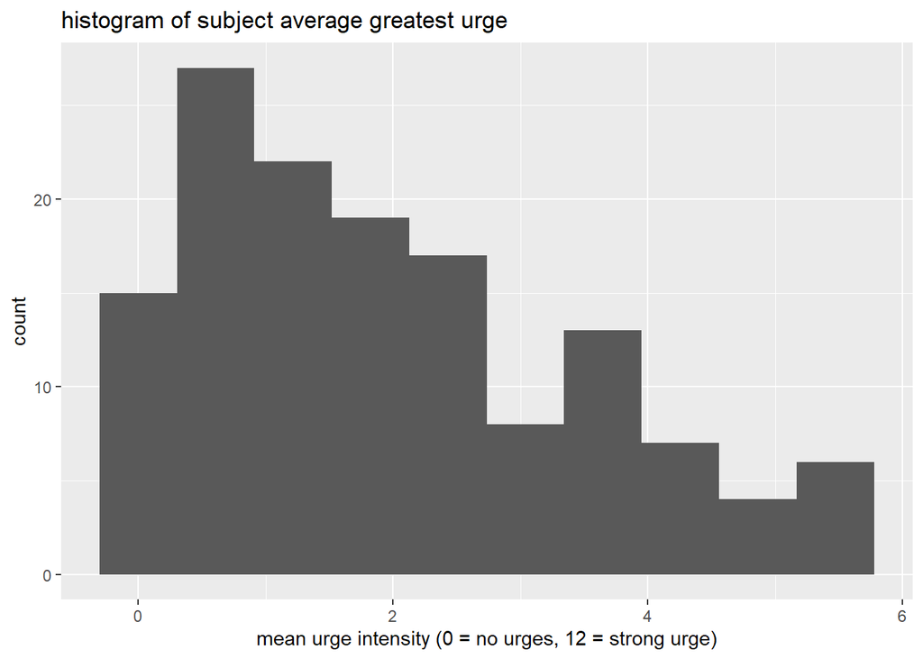

```r
ema %>%
  group_by(subid) %>%
  summarize(n = n(),
            urge_mean = mean(ema_2)) %>%
  ggplot(aes(x = urge_mean)) +
  geom_histogram(bins = 10) +
  xlab("mean urge intensity (0 = no urges, 12 = strong urge)") +
  ggtitle("histogram of subject average greatest urge")
```

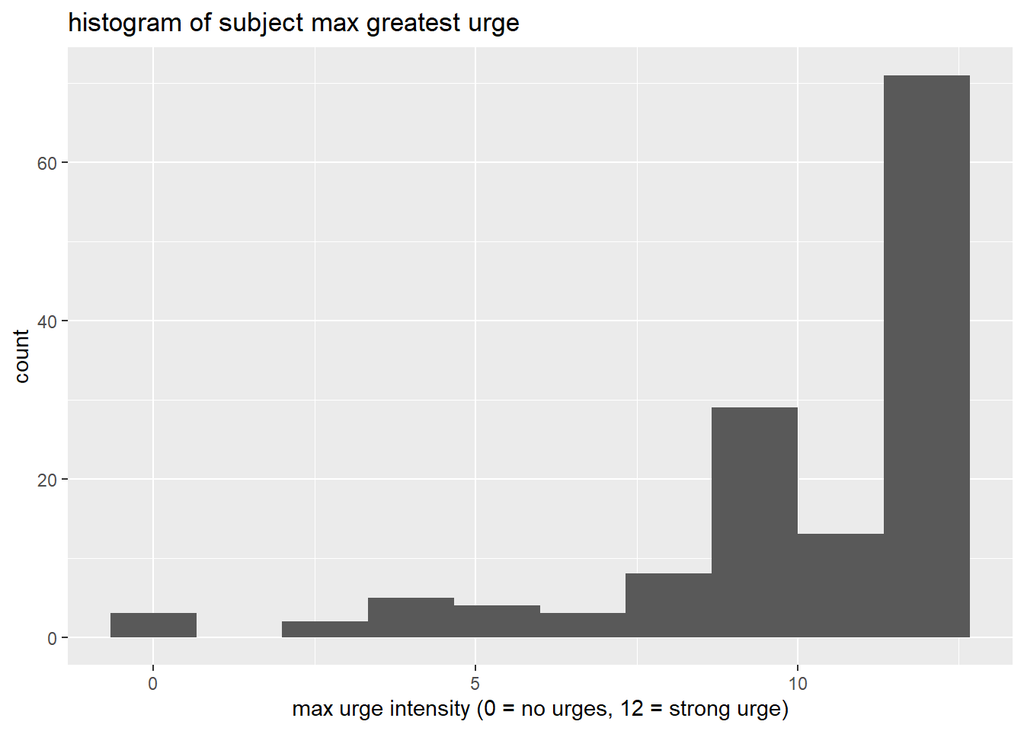

```r
ema %>%
  group_by(subid) %>%
  summarize(n = n(),
            urge_max = max(ema_2)) %>%
  ggplot(aes(x = urge_max)) +
  geom_histogram(bins = 10) +
  xlab("max urge intensity (0 = no urges, 12 = strong urge)") +
  ggtitle("histogram of subject max greatest urge")
```

Average and max reports of risk per person.

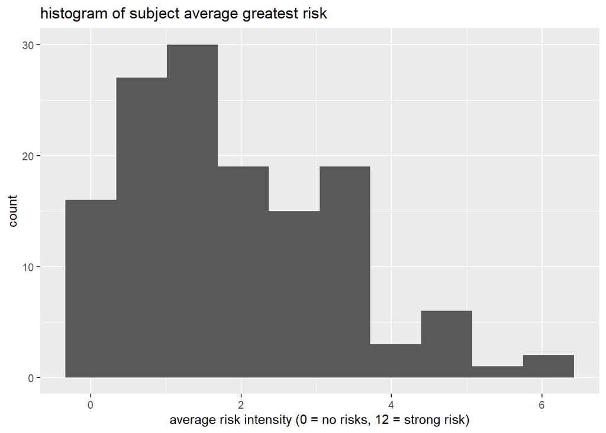

```r
ema %>%
  group_by(subid) %>%
  summarize(n = n(),
            risks_mean = mean(ema_3)) %>%
  ggplot(aes(x = risks_mean)) +
  geom_histogram(bins = 10) +
  xlab("average risk intensity (0 = no risks, 12 = strong risk)") +
  ggtitle("histogram of subject average greatest risk")
```

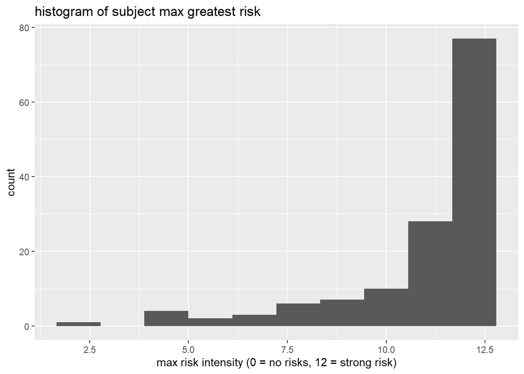

```r
ema %>%
  group_by(subid) %>%
  summarize(n = n(),
            risks_max = max(ema_3)) %>%
  ggplot(aes(x = risks_max)) +
  geom_histogram(bins = 10) +
  xlab("max risk intensity (0 = no risks, 12 = strong risk)") +
  ggtitle("histogram of subject max greatest risk")
```

Average and max reports of hassles and stressful events per person.

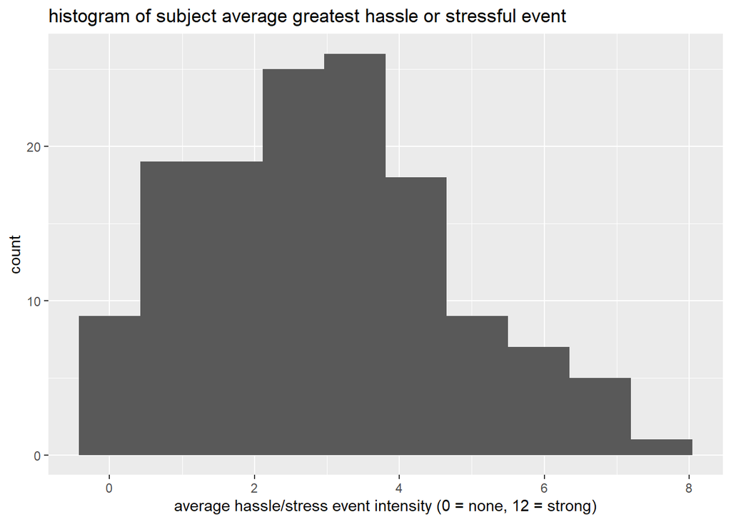

```r
ema %>%
  group_by(subid) %>%
  summarize(n = n(),
            hassle_mean = mean(ema_4)) %>%
  ggplot(aes(x = hassle_mean)) +
  geom_histogram(bins = 10) +
  xlab("average hassle/stress event intensity (0 = none, 12 = strong)") +
  ggtitle("histogram of subject average greatest hassle or stressful event")
```

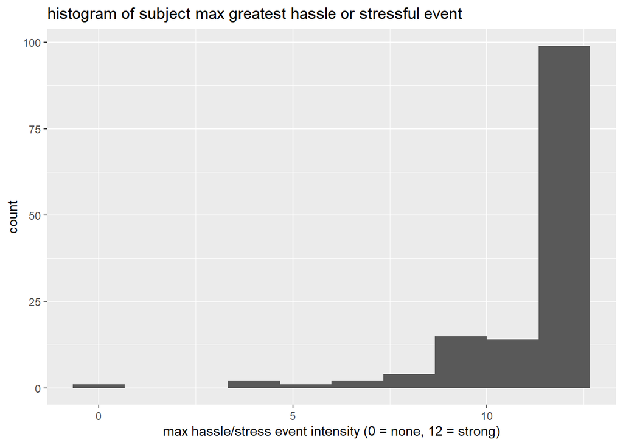

```r
ema %>%
  group_by(subid) %>%
  summarize(n = n(),
            hassle_max = max(ema_4)) %>%
  ggplot(aes(x = hassle_max)) +
  geom_histogram(bins = 10) +
  xlab("max hassle/stress event intensity (0 = none, 12 = strong)") +
  ggtitle("histogram of subject max greatest hassle or stressful event")
```

Average and max reports of pleasant and positive events per person.

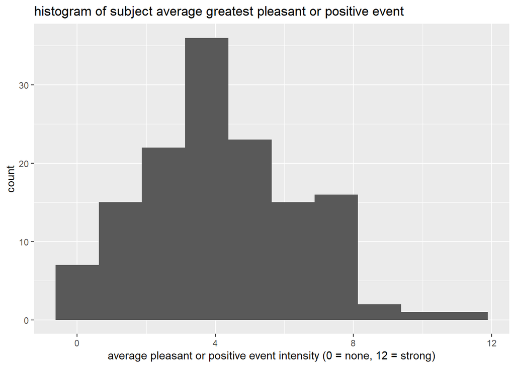

```r
ema %>%
  group_by(subid) %>%
  summarize(n = n(),
            positive_mean = mean(ema_5)) %>%
  ggplot(aes(x = positive_mean)) +
  geom_histogram(bins = 10) +
  xlab("average pleasant or positive event intensity (0 = none, 12 = strong)") +
  ggtitle("histogram of subject average greatest pleasant or positive event")
```

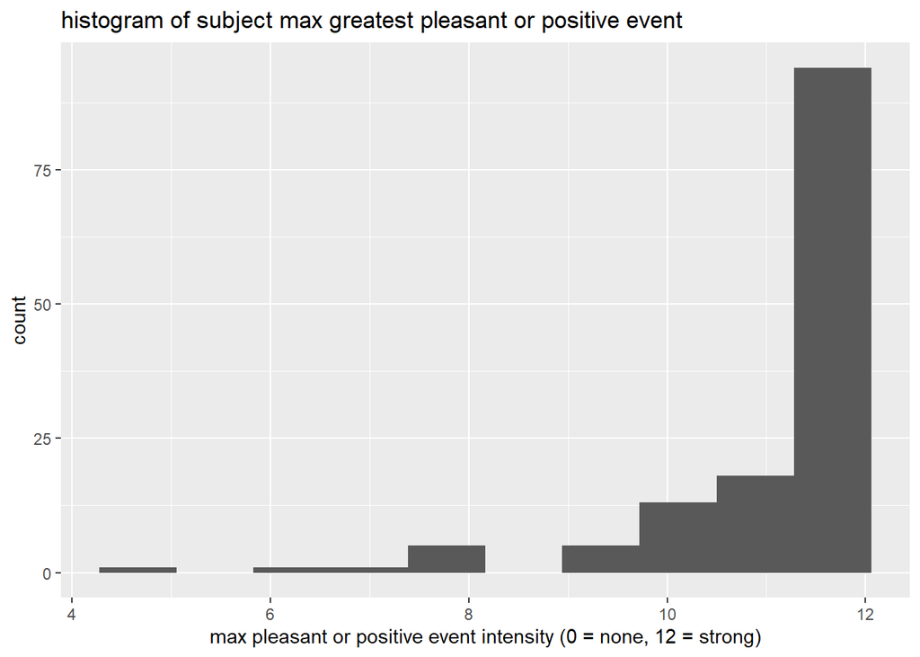

```r
ema %>%
  group_by(subid) %>%
  summarize(n = n(),
            positive_max = max(ema_5)) %>%
  ggplot(aes(x = positive_max)) +
  geom_histogram(bins = 10) +
  xlab("max pleasant or positive event intensity (0 = none, 12 = strong)") +
  ggtitle("histogram of subject max greatest pleasant or positive event")
```

Average and max reports of affect-valence per person.

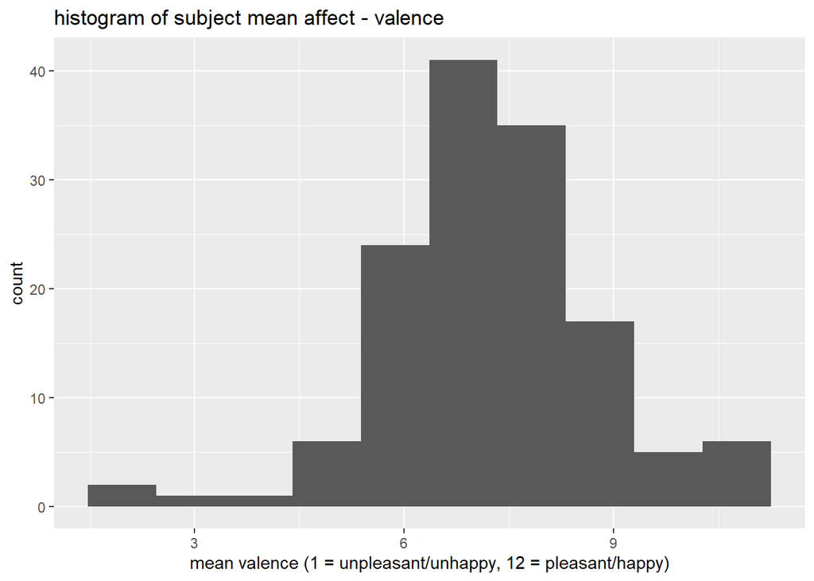

```r
ema %>%
  group_by(subid) %>%
  summarize(n = n(),
            valence_mean = mean(ema_6)) %>%
  ggplot(aes(x = valence_mean)) +
  geom_histogram(bins = 10) +
  xlab("mean valence (1 = unpleasant/unhappy, 12 = pleasant/happy)") +
  ggtitle("histogram of subject mean affect - valence")
```

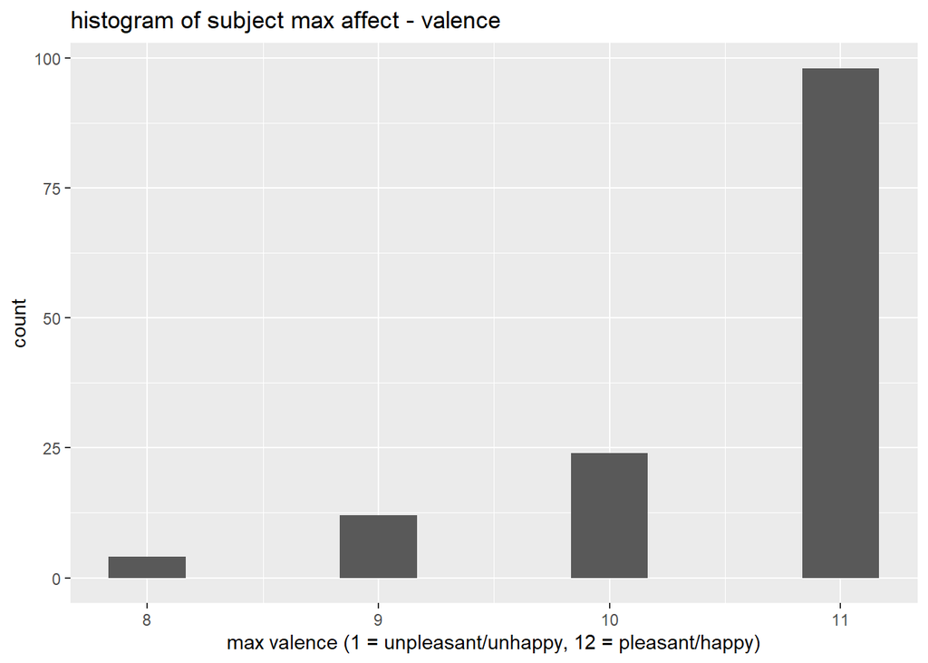

```r
ema %>%
  group_by(subid) %>%
  summarize(n = n(),
            valence_max = max(ema_6)) %>%
  ggplot(aes(x = valence_max)) +
  geom_histogram(bins = 10) +
  xlab("max valence (1 = unpleasant/unhappy, 12 = pleasant/happy)") +
  ggtitle("histogram of subject max affect - valence")
```

Average and max reports of affect-arousal per person.

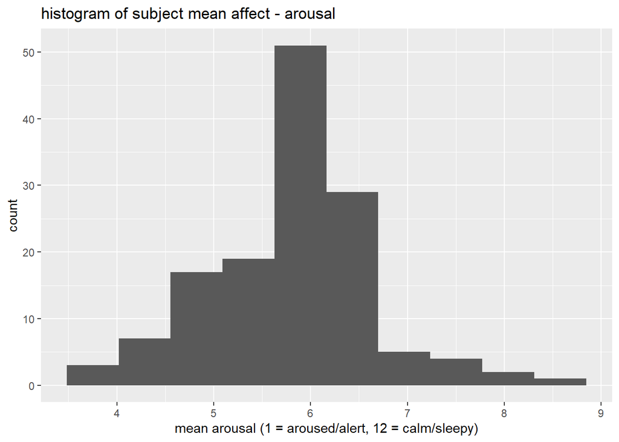

```r
ema %>%
  group_by(subid) %>%
  summarize(n = n(),
            valence_mean = mean(ema_7)) %>%
  ggplot(aes(x = valence_mean)) +
  geom_histogram(bins = 10) +
  xlab("mean arousal (1 = aroused/alert, 12 = calm/sleepy)") +
  ggtitle("histogram of subject mean affect - arousal")
```

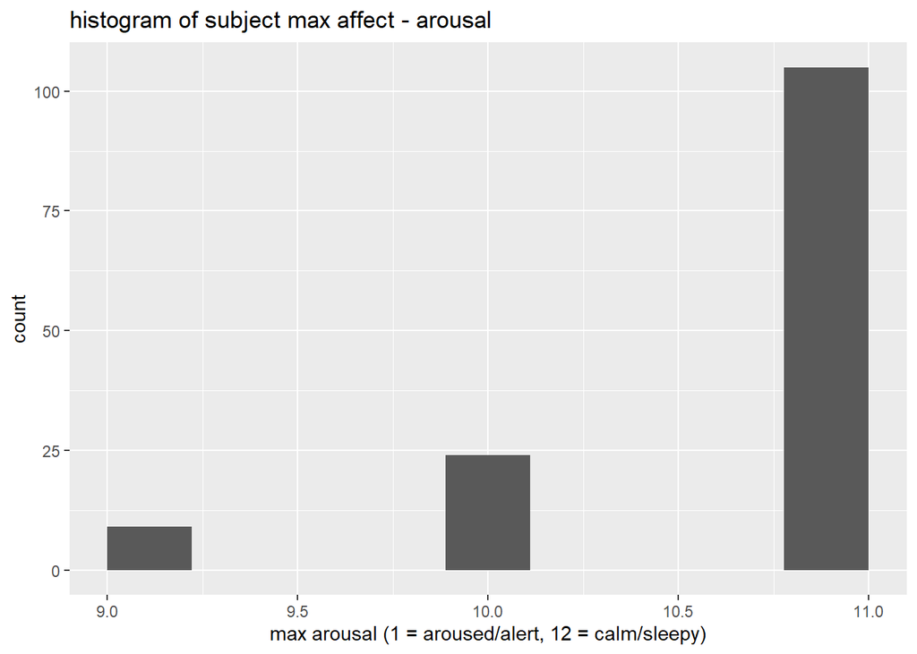

```r
ema %>%
  group_by(subid) %>%
  summarize(n = n(),
            valence_max = max(ema_7)) %>%
  ggplot(aes(x = valence_max)) +
  geom_histogram(bins = 10) +
  xlab("max arousal (1 = aroused/alert, 12 = calm/sleepy)") +
  ggtitle("histogram of subject max affect - arousal")
```

### Missing data

Table shows the number of observations with a particular pattern and the pattern (i.e., the presence/absence of each item). The bottom row shows the number of observations missing each item.

```r
ema %>%
  select(-type, -subid, -end_date, -day, -time, -start_date, -ema_1_1, -ema_1_3, -ema_1_5, -time, -day, -hour) %>%
  md.pattern(plot = FALSE)
```

```
##       ema_1 ema_2 ema_3 ema_4 ema_5 ema_6 ema_7 ema_8 ema_9 ema_10
## 10942     1     1     1     1     1     1     1     1     1      1     0
## 32835     1     1     1     1     1     1     1     0     0      0     3
## 26        1     0     0     0     0     0     0     0     0      0     9
##           0    26    26    26    26    26    26 32861 32861  32861 98739
```

### Checking for errors related to missing data

```r
#did conditional display of questions 1_1, 1_3, 1_5 work as it should?
n_missedlapse_qs <- ema %>% filter(ema_1 == 2 & is.na(ema_1_1) & is.na(ema_1_3) & is.na(ema_1_5)) %>% nrow()
#nobody answered yes that they drank but has all three follow-ups NA

n_bonuslapse_qs <- ema %>% filter(ema_1 == 1 & (!is.na(ema_1_1) | !is.na(ema_1_3) | !is.na(ema_1_5))) %>% nrow()
#nobody answered no that they didn't drink but has any response to a follow-up Q
#so, yes, conditional display of these questions worked

#some follow up questions are missing from this dataframe (ema 1_2, 1_4)
#these were collapsed into other items

#did morning and evening surveys have what they should?
n_missingmorning_qs <- ema %>% filter(type == 1 & is.na(ema_8) & is.na(ema_9) & is.na(ema_10)) %>% nrow()
#6 people have NAs for all these questions
#but they have NAs for all the other questions, too... how many are filled in lapses
n_missingmorning_qs_lapsed <- ema %>% filter(type == 1 & is.na(ema_8) & is.na(ema_9) & is.na(ema_10)) %>% filter(ema_1 == 2) %>% nrow()

#did evening surveys not have what they shouldn't?
n_bonusmorning_qs <-  ema %>% filter(type == 2 & (!is.na(ema_8) | !is.na(ema_9) | !is.na(ema_10))) %>% nrow()
#yes
```

There are 0 instances of changed lapse labels (people who did not report a lapse but have responses for questions about the lapse)

```r
ema %>%filter(ema_1 == 1 & (!is.na(ema_1_1) | !is.na(ema_1_3) | !is.na(ema_1_5))) %>%
  select(subid, day, ema_1, ema_1_1, ema_1_3, ema_1_5, ema_2, ema_3, ema_4, ema_5, ema_6, ema_7, ema_8) %>% kable()
```

| subid | day | ema_1 | ema_1_1 | ema_1_3 | ema_1_5 | ema_2 | ema_3 | ema_4 | ema_5 | ema_6 | ema_7 | ema_8 |
| --- | --- | --- | --- | --- | --- | --- | --- | --- | --- | --- | --- | --- |

Other errors checked for:  
* The number of people who reported a lapse but have no responses for the lapse questions is 0.  
* The number of morning surveys that don’t have responses to questions 8, 9, and 10 is 3.  
+ Of these, 3 were lapses, and were probably filled in based on in-lab information.  
* The number of evening surveys that have responses to questions 8, 9, and 10 is 0.

### Survey completion times

```r
survey_duration_summary <- ema %>% mutate(survey_duration = end_date - start_date) %>%
  mutate(survey_duration_mins = as.numeric(survey_duration / 60)) %>%
  select(subid, survey_duration_mins) %>%
  varDescribe() %>% filter(vars == 2)

n_under3mins <- ema %>% mutate(survey_duration = end_date - start_date) %>%
  mutate(survey_duration_mins = as.numeric(survey_duration / 60)) %>%
  filter(survey_duration_mins < 3) %>% nrow()

n_morethan1hr <- ema %>% mutate(survey_duration = end_date - start_date) %>%
  mutate(survey_duration_hours = as.numeric(survey_duration / 60 / 60)) %>%
  arrange(-survey_duration) %>%
  select(survey_duration, survey_duration_hours, subid, everything()) %>%
  filter(survey_duration_hours >1) %>% nrow()

n_morethan3hr <- ema %>% mutate(survey_duration = end_date - start_date) %>%
  mutate(survey_duration_hours = as.numeric(survey_duration / 60 / 60)) %>%
  arrange(-survey_duration) %>%
  select(survey_duration, survey_duration_hours, subid, everything()) %>%
  filter(survey_duration_hours >3) %>% nrow()

n_morethan5hr <-ema %>% mutate(survey_duration = end_date - start_date) %>%
  mutate(survey_duration_hours = as.numeric(survey_duration / 60 / 60)) %>%
  arrange(-survey_duration) %>%
  select(survey_duration, survey_duration_hours, subid, everything()) %>%
  filter(survey_duration_hours >5) %>% nrow()

n_slowseveraltimes <-  ema %>% mutate(survey_duration = end_date - start_date) %>%
  mutate(survey_duration_mins = as.numeric(survey_duration / 60)) %>%
  arrange(-survey_duration) %>%
  select(survey_duration, survey_duration_mins, subid, everything()) %>%
  filter(survey_duration_mins > 3) %>% group_by(subid) %>%
  summarise(n = n()) %>% filter(n > 1) %>% nrow()

n_slowalot <-  ema %>% mutate(survey_duration = end_date - start_date) %>%
  mutate(survey_duration_mins = as.numeric(survey_duration / 60)) %>%
  arrange(-survey_duration) %>%
  select(survey_duration, survey_duration_mins, subid, everything()) %>%
  filter(survey_duration_mins > 3) %>% group_by(subid) %>%
  summarise(n = n()) %>% filter(n > 5) %>% nrow()

n_slowtoomuch <-  ema %>% mutate(survey_duration = end_date - start_date) %>%
  mutate(survey_duration_mins = as.numeric(survey_duration / 60)) %>%
  arrange(-survey_duration) %>%
  select(survey_duration, survey_duration_mins, subid, everything()) %>%
  filter(survey_duration_mins > 3) %>% group_by(subid) %>%
  summarise(n = n()) %>% filter(n > 10) %>% nrow()
```

Most surveys (42719) were completed in under 3 minutes. Among surveys that took less than three minutes, distribution is more normal, though right skewed.

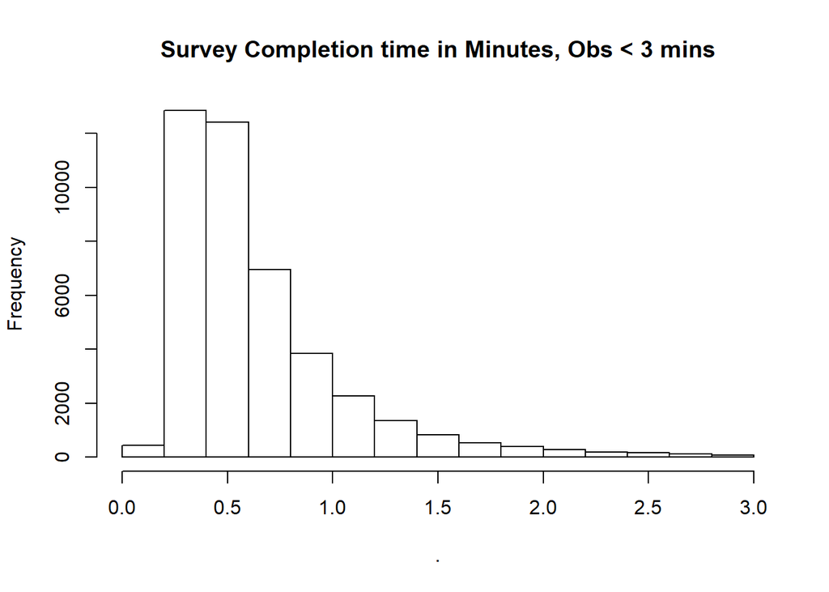

```r
ema %>% mutate(survey_duration = end_date - start_date) %>%
  mutate(survey_duration_mins = as.numeric(survey_duration / 60)) %>%
  filter(survey_duration_mins < 3) %>%
  .$survey_duration_mins %>% hist(main = 'Survey Completion time in Minutes, Obs < 3 mins')
```

Some surveys were completed exteremly slowly:

- 110 surveys took more than an hour
- 25 surveys took more than three hours
- 16 surveys took more than five hours

```r
ema %>% mutate(survey_duration = end_date - start_date) %>%
  mutate(survey_duration_hours = as.numeric(survey_duration / 60 / 60)) %>%
  arrange(-survey_duration) %>%
  select(subid, day, survey_duration_hours, type, ema_1, ema_1_5, ema_2, ema_3, ema_4, ema_5, ema_6, ema_7) %>%
  filter(survey_duration_hours >5) %>% kable()
```

| subid | day | survey_duration_hours | type | ema_1 | ema_1_5 | ema_2 | ema_3 | ema_4 | ema_5 | ema_6 | ema_7 |
| --- | --- | --- | --- | --- | --- | --- | --- | --- | --- | --- | --- |
| 66 | 2018-08-13 | 69.984444 | 2 | 1 | NA | 1 | 0 | 1 | 2 | 10 | 10 |
| 234 | 2019-08-28 | 24.238056 | 2 | 2 | 3 | NA | NA | NA | NA | NA | NA |
| 53 | 2018-04-11 | 19.962222 | 1 | 1 | NA | 5 | 10 | 4 | 3 | 3 | 3 |
| 269 | 2019-10-21 | 11.853889 | 2 | 1 | NA | 9 | 6 | 9 | 6 | 2 | 6 |
| 188 | 2019-04-06 | 11.286944 | 2 | 1 | NA | 0 | 0 | 0 | 0 | 6 | 6 |
| 27 | 2018-02-07 | 11.052778 | 2 | 1 | NA | 0 | 0 | 1 | 0 | 6 | 6 |
| 150 | 2018-10-31 | 9.705833 | 2 | 2 | 2 | 4 | 2 | 2 | 2 | 7 | 9 |
| 98 | 2018-08-17 | 8.797222 | 2 | 1 | NA | 0 | 0 | 1 | 0 | 6 | 6 |
| 138 | 2018-12-16 | 8.790000 | 2 | 1 | NA | 0 | 0 | 0 | 0 | 8 | 8 |
| 189 | 2019-04-21 | 8.011111 | 2 | 1 | NA | 0 | 3 | 3 | 5 | 6 | 6 |
| 137 | 2018-10-24 | 7.869722 | 2 | 1 | NA | 3 | 5 | 7 | 6 | 8 | 8 |
| 39 | 2018-03-21 | 7.768056 | 2 | 1 | NA | 4 | 4 | 4 | 4 | 5 | 9 |
| 156 | 2018-11-07 | 6.722222 | 1 | 1 | NA | 0 | 0 | 0 | 8 | 11 | 11 |
| 137 | 2018-11-04 | 6.263889 | 2 | 1 | NA | 9 | 7 | 6 | 7 | 8 | 7 |
| 80 | 2018-07-23 | 5.504722 | 2 | 1 | NA | 4 | 4 | 4 | 6 | 9 | 6 |
| 80 | 2018-08-04 | 5.022500 | 2 | 1 | NA | 3 | 1 | 0 | 5 | 10 | 9 |

Some people were especially slow:

- 128 people took more than 3 minutes more than once.
- 69 people took more than 3 minutes more than five times.
- 33 people took more than 3 minutes more than ten times

A few people regularly took more than 10 minutes.

```r
ema %>% mutate(survey_duration = end_date - start_date) %>%
  mutate(survey_duration_mins = as.numeric(survey_duration / 60)) %>%
  select(survey_duration, survey_duration_mins, subid, everything()) %>%
  filter(survey_duration_mins > 10) %>% group_by(subid) %>%
  summarise(n_morethan10minutes = n()) %>% filter(n_morethan10minutes > 5) %>% kable()
```

| subid | n_morethan10minutes |
| --- | --- |
| 10 | 7 |
| 18 | 6 |
| 30 | 10 |
| 33 | 7 |
| 37 | 15 |
| 39 | 11 |
| 58 | 16 |
| 77 | 8 |
| 80 | 7 |
| 90 | 7 |
| 92 | 7 |
| 119 | 6 |
| 130 | 6 |
| 150 | 17 |
| 156 | 7 |
| 185 | 8 |
| 208 | 9 |
| 225 | 12 |
| 236 | 6 |
| 255 | 7 |
| 269 | 6 |

```r
n_lessthan15secs <- ema %>% mutate(survey_duration = end_date - start_date) %>%
  mutate(survey_duration_secs = as.numeric(survey_duration)) %>%
  select(survey_duration_secs,subid, everything()) %>%
  filter(survey_duration_secs < 15) %>% nrow()

n_lessthan13secs <- ema %>% mutate(survey_duration = end_date - start_date) %>%
  mutate(survey_duration_secs = as.numeric(survey_duration)) %>%
  select(survey_duration_secs,subid, everything()) %>%
  filter(survey_duration_secs < 13) %>% nrow()

n_lessthan11secs <- ema %>% mutate(survey_duration = end_date - start_date) %>%
  mutate(survey_duration_secs = as.numeric(survey_duration)) %>%
  select(survey_duration_secs,subid, everything()) %>%
  filter(survey_duration_secs < 11) %>% nrow()


n_fastseveraltimes <- ema %>% mutate(survey_duration = end_date - start_date) %>%
  mutate(survey_duration_hours = as.numeric(survey_duration / 60 / 60)) %>%
  arrange(-survey_duration) %>%
  select(survey_duration, survey_duration_hours, subid, everything()) %>%
  filter(survey_duration < 13) %>% group_by(subid) %>%
  summarize(n = n()) %>% filter(n > 1) %>% nrow()
#34 people took less than 15 seconds more than once

n_fastalot <- ema %>% mutate(survey_duration = end_date - start_date) %>%
  mutate(survey_duration_hours = as.numeric(survey_duration / 60 / 60)) %>%
  arrange(-survey_duration) %>%
  select(survey_duration, survey_duration_hours, subid, everything()) %>%
  filter(survey_duration < 13) %>% group_by(subid) %>%
  summarize(n = n()) %>% filter(n > 5) %>% nrow()

n_fasttoomuch <- ema %>% mutate(survey_duration = end_date - start_date) %>%
  mutate(survey_duration_hours = as.numeric(survey_duration / 60 / 60)) %>%
  arrange(-survey_duration) %>%
  select(survey_duration, survey_duration_hours, subid, everything()) %>%
  filter(survey_duration < 13) %>% group_by(subid) %>%
  summarize(n = n()) %>% filter(n > 10) %>% nrow()

n_fast_lapses <- ema %>% mutate(survey_duration = end_date - start_date) %>%
  mutate(survey_duration_secs = as.numeric(survey_duration)) %>%
  select(subid, day, survey_duration_secs, type, ema_1, ema_1_5, ema_2, ema_3, ema_4, ema_5, ema_6, ema_7) %>%
  filter(survey_duration_secs < 15) %>% filter(ema_1 == 2) %>% nrow()
```

Other surveys were completed very quickly.

0 of the surveys that were completed in under 15 seconds were lapses.

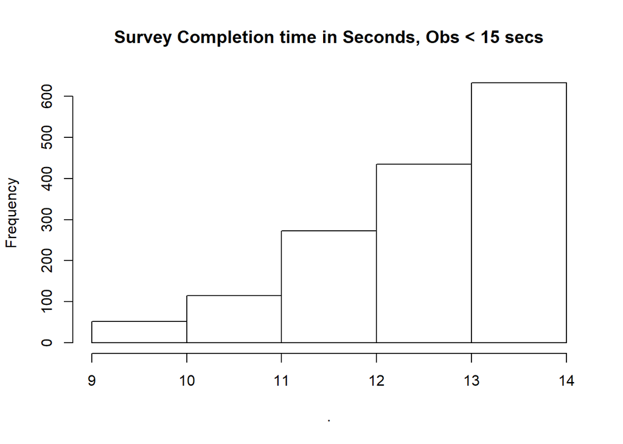

```r
ema %>% mutate(survey_duration = end_date - start_date) %>%
  mutate(survey_duration_secs = as.numeric(survey_duration)) %>%
  filter(survey_duration_secs < 15) %>%
  .$survey_duration_secs %>% hist(main = 'Survey Completion time in Seconds, Obs < 15 secs', breaks = 5)
```

A few people regularly took 10 seconds or less.

| subid | n_lessthan10secs |
| --- | --- |
| 86 | 4 |
| 92 | 10 |
| 187 | 3 |
| 240 | 3 |
| 243 | 3 |
| 259 | 17 |

## Looking at lapses (y)

Timing of lapses

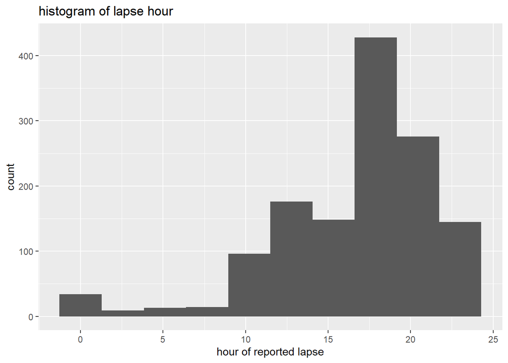

```r
ema %>%
  filter(!is.na(ema_1_1)) %>%
  mutate(lapse_hour = hour(ema_1_1)) %>%
  ggplot(aes(x = lapse_hour)) +
  geom_histogram(bins = 10) +
  xlab("hour of reported lapse") +
  ggtitle("histogram of lapse hour")
```

```r
ema %>%
  filter(!is.na(ema_1_1)) %>%
  mutate(lapse_hour = hour(ema_1_1)) %>%
  summarize(median_lapse_time = median(lapse_hour, na.rm = TRUE))

ema %>%
  filter(!is.na(ema_1_1)) %>%
  mutate(lapse_hour = hour(ema_1_1)) %>%
  tabyl(lapse_hour, show_na = TRUE) %>%
  filter(lapse_hour > 6) %>%
  mutate(percent = round(percent, 2))
```

```
##   median_lapse_time
## 1                18
##  lapse_hour   n percent
##           7   3    0.00
##           8  11    0.01
##           9  16    0.01
##          10  38    0.03
##          11  42    0.03
##          12  61    0.05
##          13  46    0.03
##          14  69    0.05
##          15  75    0.06
##          16  73    0.05
##          17 126    0.09
##          18 144    0.11
##          19 158    0.12
##          20 132    0.10
##          21 144    0.11
##          22  81    0.06
##          23  64    0.05
```

There are 1343 lapses in the ema dataset and 972 lapses in the lapse dataset.

In the ema dataset, most people have just one lapse per day, with an average of 1.32 (range 1 - 7).

```r
#in y lapses
lapses$day <- lapses$utc %>% #converting into human readable form
  as.numeric %>%
  as.POSIXct(tz='America/Chicago', origin="1970-01-01")
#note, the time has been removed

##SARAH where did this come from?
y_TooManylapses_per_dayy <- lapses %>% group_by(subid, day) %>%
  filter(lapse == 1) %>%
  summarize(n = n()) %>% filter(n > 1) %>% nrow()

lapsesPerPerson <- lapses%>% group_by(subid) %>%
  filter(lapse == 1) %>%
  summarize(n = n()) %>%
  summarize(mean_nlapses = mean(n),
            max_nlapses = max(n),
            min_nlapses = min(n))
```

##SARAH we no longer have a features file?

```r
#Do the X dataset and y dataset have the same number of observations? `r nrow(X) #== nrow(lapses)`
```

# Looking at the id dataset

```r
# ##SARAH doesnt work
# #reloading just in case?
# id <- read_rds(file.path(data_path, "ds_id.rds")) %>%
#   glimpse()
# dim(id)
# #154 rows
#
# id %>% group_by(subid) %>%
#   summarize(n = n()) %>% nrow()
# #154 people
#
# #vs for ema
# ema %>% group_by(subid) %>%
#   summarize(n = n()) %>% nrow()
# #also 154
#
# #looking at demographics
# id %>% select(contains("dem")) %>% varDescribe()
# #some missing values on Dem2_4, 6, 8
# #also where are Dem 2_1, 3, 5, 7?
# #dem_7 must be income
# ##SARAH error might be here?
# #hist(id$dem_7)
#
# #looking at alcohol use history
# id %>% select(contains("auh")) %>% varDescribe()
# #no missing
#
# #looking at assist
# id %>% select(contains("assist")) %>% varDescribe()
# #no missing
# #some insane kurtosis and skew for the self-efficacy
#
# #DSM
# id %>% .$scale_dtm5_tot %>% hist()
# #left skew but not too bad
#
# #DTS
# id %>% select(contains("dts")) %>% varDescribe()
# #looks good
#
# #FAD
# id %>% select(contains("fad")) %>% varDescribe()
# #why are the maxes here all over the place? what was the scale?
# #otherwise no problems
#
# #ASI
# id %>% select(contains("asi")) %>% varDescribe()
# #looks good
#
# #SCL
# id %>% select(contains("scl")) %>% varDescribe()
# #mostly normal excelt Pho and Ang are kurtotic
# #most people scored very low on both
#
# #MPS
# id %>% select(contains("mps")) %>% varDescribe()
# #looks normal
#
# #else
# id %>% select(-contains("mps"), -contains("scl"), -contains("asi"),
#               -contains("fad"), -contains("dts"), -contains("assist"),
#               -contains("auh"), -contains("dsm"), -contains("dem"),
#               -contains("sub"), -contains("utc")) %>% varDescribe()
# #all good
```

- age is ok
- gender is ok
- trait level time 0 is ok as just intercept
- trait level time 0 is a source of interaction, too
- id is the id labels, includes things like the DSM-5 checklist, demographics
- SR is self-report varying